# Explore data of Coux et al. 2016

The data contains 5 different tables, that we can group in three categories:

1. plant-pollinator interaction list at each site
2. plant and pollinator abundances (one table per guild)
3. plant and pollinator traits (one table per guild)

We look at each of these categories in what follows.

```r
data <- tar_read(data_coux)
head(data$interaction)
```

```
       site     pollinator    plant links
1 blabrolee    a_mellifera alcea_sp     2
2 blabrolee        e_tenax alcea_sp     0
3 blabrolee i_promissorius alcea_sp     0
4 blabrolee     l_sordidum alcea_sp     0
5 blabrolee     n_producta alcea_sp     0
6 blabrolee  p_pseudorudis alcea_sp     0
```

## Abundances

We have plant presence/absence per site — despite the name, this is binary (1/0), not a count.

```r
str(data$plant_abundance)
```

```
'data.frame':   21 obs. of  15 variables:
 $ site                : chr  "blabrolee" "blahamlak" "blaheslee" "blajergre" ...
 $ lolium_sp           : int  1 1 1 1 1 1 1 1 1 1 ...
 $ daucus_carota       : int  1 0 1 0 0 1 0 0 0 0 ...
 $ chenopodium_album   : int  0 1 1 1 0 0 1 0 0 0 ...
 $ cordyline_sp        : int  0 0 1 0 1 0 1 0 0 0 ...
 $ alcea_sp            : int  1 0 1 0 0 1 0 1 0 0 ...
 $ rubus_fruticosus    : int  1 1 0 0 0 0 1 0 1 0 ...
 $ alnus_sp            : int  0 1 0 0 0 0 1 0 0 0 ...
 $ malva_spp           : int  0 1 1 0 0 0 0 0 0 0 ...
 $ taraxacum_officinale: int  1 1 1 0 1 1 1 1 1 1 ...
 $ raphanus_sp         : int  0 1 1 0 0 0 1 1 0 1 ...
 $ cirsium_vulgare     : int  1 1 1 0 1 1 1 1 1 1 ...
 $ eucalyptus_globulus : int  1 1 1 0 0 0 1 0 1 1 ...
 $ eucalyptus_nitens   : int  1 1 1 1 1 0 1 0 0 1 ...
 $ trifolium_sp        : int  1 1 1 0 1 1 1 0 1 1 ...
```

And pollinator abundances, which are actual counts.

```r
str(data$pollinator_abundance)
```

```
'data.frame':   21 obs. of  17 variables:
 $ site             : chr  "blabrolee" "blahamlak" "blaheslee" "blajergre" ...
 $ a_mellifera      : int  248 115 522 53 10 90 335 21 0 39 ...
 $ b_terrestris     : int  0 0 49 18 0 0 36 0 23 0 ...
 $ c_stygia         : int  0 0 0 0 0 0 0 0 0 0 ...
 $ c_vicina         : int  0 0 0 0 0 0 0 0 0 0 ...
 $ d_platura        : int  0 21 52 0 0 0 114 0 0 0 ...
 $ e_tenax          : int  5 0 5 0 0 0 0 0 0 0 ...
 $ h_hochstetteri   : int  0 7 0 0 0 0 0 0 0 0 ...
 $ i_promissorius   : int  2 0 2 0 0 0 0 0 0 0 ...
 $ l_sordidum       : int  3625 0 808 0 0 522 380 202 0 156 ...
 $ m_novae_zelandiae: int  0 0 0 0 8 0 7 0 0 0 ...
 $ n_producta       : int  7 0 5 0 0 0 0 0 0 0 ...
 $ o_atrovirens     : int  0 27 0 0 2 4 0 0 0 0 ...
 $ o_varia          : int  0 10 6 0 0 0 0 0 2 0 ...
 $ p_marginata      : int  0 0 1 7 0 0 1 0 0 0 ...
 $ p_pseudorudis    : int  30 60 59 0 0 0 0 0 0 0 ...
 $ t_orthodoxus     : int  0 1 1 0 0 0 0 0 0 0 ...
```

### Plant occurence

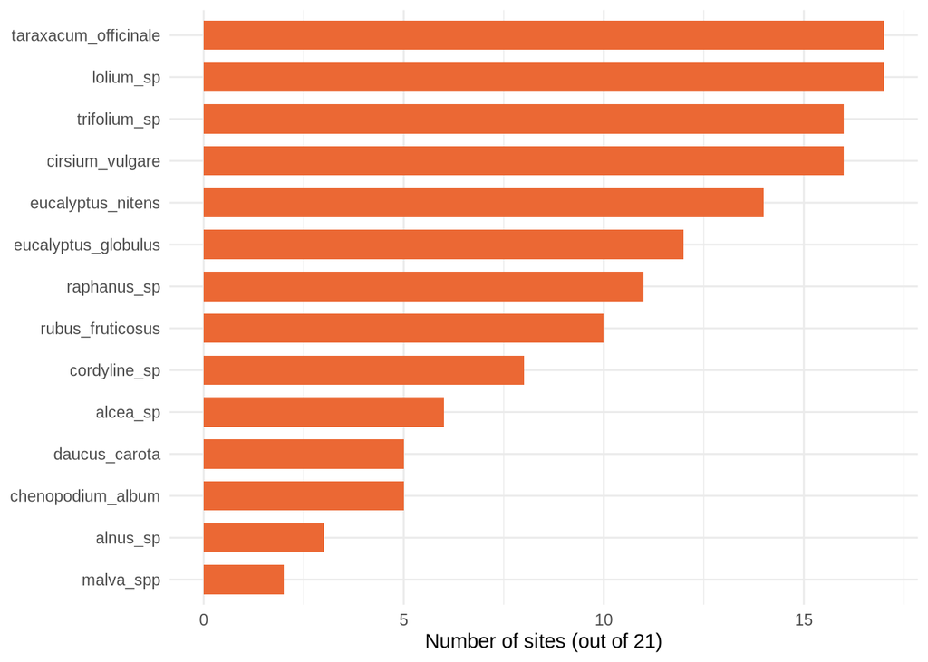

```r
n_sites_abundance <- n_distinct(data$plant_abundance$site)

plant_occupancy <- data$plant_abundance |>
  pivot_longer(-site, names_to = "plant", values_to = "present") |>
  group_by(plant) |>
  summarise(n_sites = sum(present), .groups = "drop") |>
  mutate(plant = fct_reorder(plant, n_sites))

ggplot(plant_occupancy, aes(x = plant, y = n_sites)) +
  geom_col(fill = guild_colors[["plant"]], width = 0.7) +
  coord_flip() +
  labs(
    x = NULL, y = paste0("Number of sites (out of ", n_sites_abundance, ")")
  )
```

### Pollinator abundance

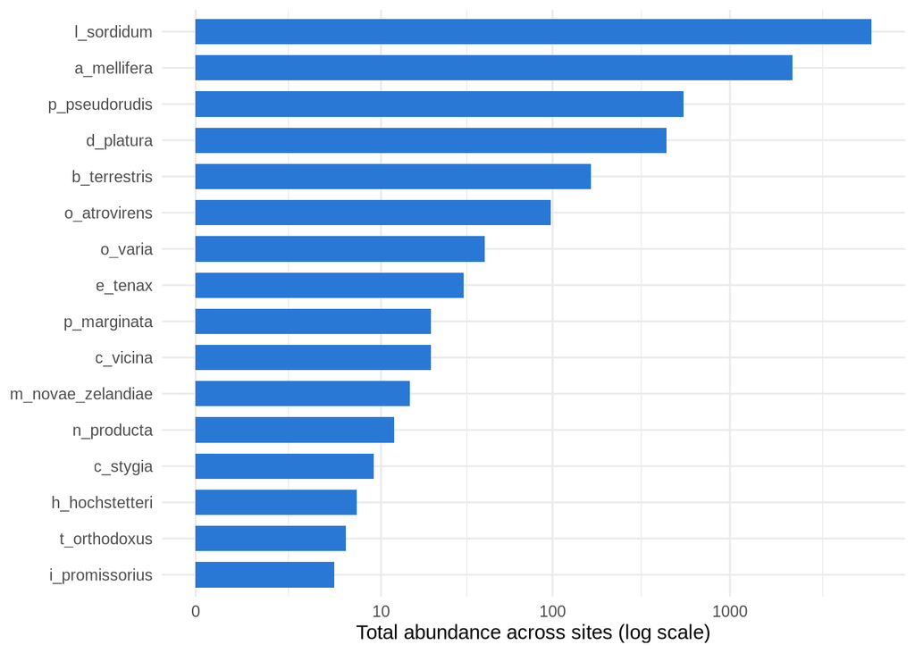

```r
pollinator_totals <- data$pollinator_abundance |>
  pivot_longer(-site, names_to = "pollinator", values_to = "abundance") |>
  group_by(pollinator) |>
  summarise(total_abundance = sum(abundance), .groups = "drop") |>
  mutate(pollinator = fct_reorder(pollinator, total_abundance))

ggplot(pollinator_totals, aes(x = pollinator, y = total_abundance)) +
  geom_col(fill = guild_colors[["pollinator"]], width = 0.7) +
  coord_flip() +
  scale_y_continuous(trans = "log1p", breaks = c(0, 10, 100, 1000, 10000)) +
  labs(
    x = NULL, y = "Total abundance across sites (log scale)"
  )
```

## Interactions

Here is what the raw data looks like.

The columns correspond to

- `site`: the community (21 sites)
- `pollinator`: the pollinator species (16 species across all sites)
- `plant`: the plant species (14 species across all sites)
- `links`: the number of interaction events (visits) observed between that plant and that pollinator at that site (61% show zero observed visits).

**Note**

`data_coux` is already cleaned by `clean_coux_data()`: species names are lowercased everywhere (pollinator names are capitalised and plant names inconsistently so in the raw data), and `alnus_glutinosa`/`alnus_serrulate` are merged into a single `alnus_sp`. The raw interaction table has `alnus_glutinosa` at site `blahamlak` with no matching trait/abundance row, and `alnus_serrulate` at `crobirlee`/`crostelee` joining fine. Since no site uses both names, we treat all three as the same plant recorded under two names. See `clean_coux_data()` in `R/analyse-coux.R` for details; use `tar_read(data_coux_raw)` to see the uncleaned version.

We have coded a function to compute species level network metrics using the `bipartite::specieslevel` function.

```r
net_metrics <- tar_read(net_metrics)
net_metrics
```

```
# A tibble: 232 × 7
   site      species             degree normalised_degree d_prime guild       hs
   <chr>     <chr>                <dbl>             <dbl>   <dbl> <chr>    <dbl>
 1 blabrolee a_mellifera              7             0.778  0.177  pollina… 0.190
 2 blabrolee e_tenax                  1             0.111  1      pollina… 1
 3 blabrolee i_promissorius           3             0.333  0.144  pollina… 0.5
 4 blabrolee l_sordidum               2             0.222  0.207  pollina… 0.744
 5 blabrolee n_producta               4             0.444  0.209  pollina… 0.435
 6 blabrolee p_pseudorudis            3             0.333  0.0227 pollina… 0.5
 7 blabrolee alcea_sp                 1             0.167  0      plant    1
 8 blabrolee cirsium_vulgare          3             0.5    0.0427 plant    0.556
 9 blabrolee daucus_carota            1             0.167  0.468  plant    1
10 blabrolee eucalyptus_globulus      1             0.167  0      plant    1
# ℹ 222 more rows
```

### Site richness

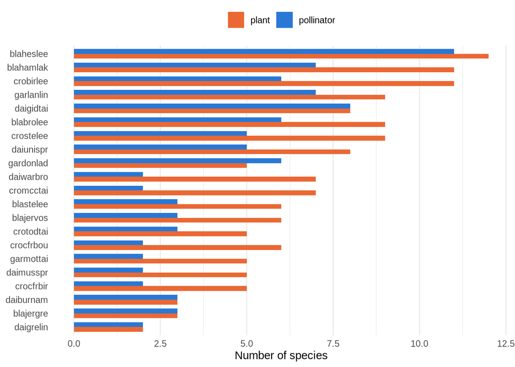

```r
site_richness <- data$interaction |>
  group_by(site) |>
  summarise(
    pollinator = n_distinct(pollinator),
    plant = n_distinct(plant),
    .groups = "drop"
  ) |>
  pivot_longer(
    c(pollinator, plant),
    names_to = "guild",
    values_to = "n_species"
  ) |>
  mutate(site = fct_reorder(site, n_species, .fun = sum))

ggplot(site_richness, aes(x = site, y = n_species, fill = guild)) +
  geom_col(position = "dodge", width = 0.7) +
  coord_flip() +
  scale_fill_manual(values = guild_colors) +
  labs(x = NULL, y = "Number of species", fill = NULL) +
  theme(panel.grid.major.y = element_blank(), legend.position = "top")
```

Sites range from a few species to much richer communities. Network size itself is a potential confound to keep in mind in later analyses. We also note that plant and pollinator richness are strongly positively correlated.

### Interaction matrices

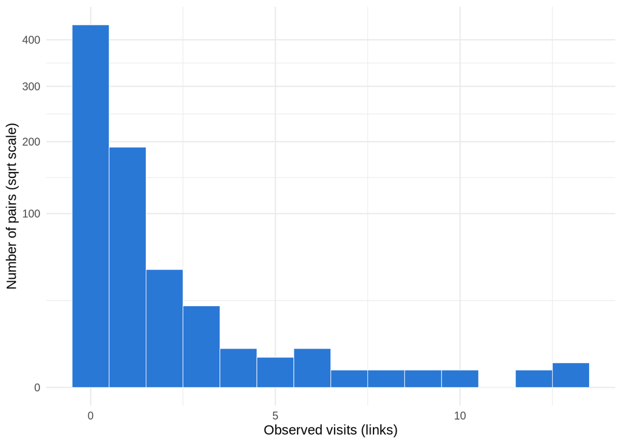

```r
ggplot(data$interaction, aes(x = links)) +
  geom_histogram(
    binwidth = 1, fill = guild_colors[["pollinator"]],
    color = "white", linewidth = 0.2
  ) +
  scale_y_continuous(trans = "sqrt") +
  labs(
    x = "Observed visits (links)", y = "Number of pairs (sqrt scale)"
  )
```

### Degree distribution by guild

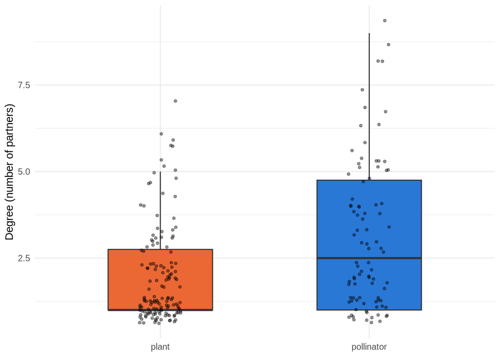

```r
ggplot(net_metrics, aes(x = guild, y = degree, fill = guild)) +
  geom_boxplot(width = 0.5, outlier.shape = NA) +
  geom_jitter(width = 0.1, alpha = 0.4, size = 1) +
  scale_fill_manual(values = guild_colors) +
  labs(
    x = NULL, y = "Degree (number of partners)"
  ) +
  theme(legend.position = "none")
```

### Degree per species

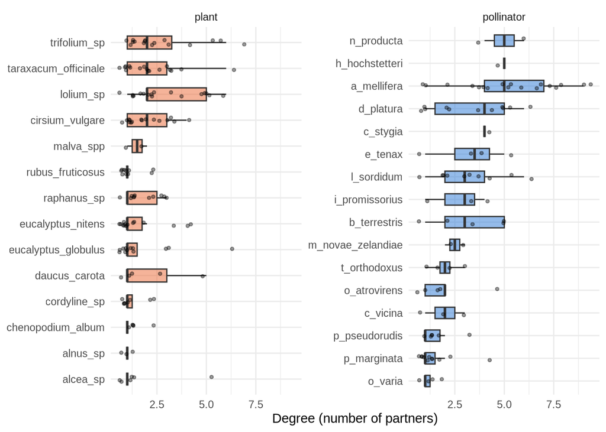

```r
degree_by_species <- net_metrics |>
  mutate(species = fct_reorder(species, degree, .fun = median))

ggplot(degree_by_species, aes(x = species, y = degree, fill = guild)) +
  geom_boxplot(width = 0.5, outlier.shape = NA, alpha = 0.5) +
  geom_jitter(width = 0.1, alpha = 0.4, size = 1) +
  scale_fill_manual(values = guild_colors) +
  facet_wrap(~guild, scales = "free_y") +
  coord_flip() +
  labs(x = NULL, y = "Degree (number of partners)") +
  theme(legend.position = "none")
```

### Normalised degree per species

Raw degree is mechanically capped by how many species a site has at all, so we also look at normalised degree — degree scaled by the number of possible partners at that site — which partially controls for that site-richness confound.

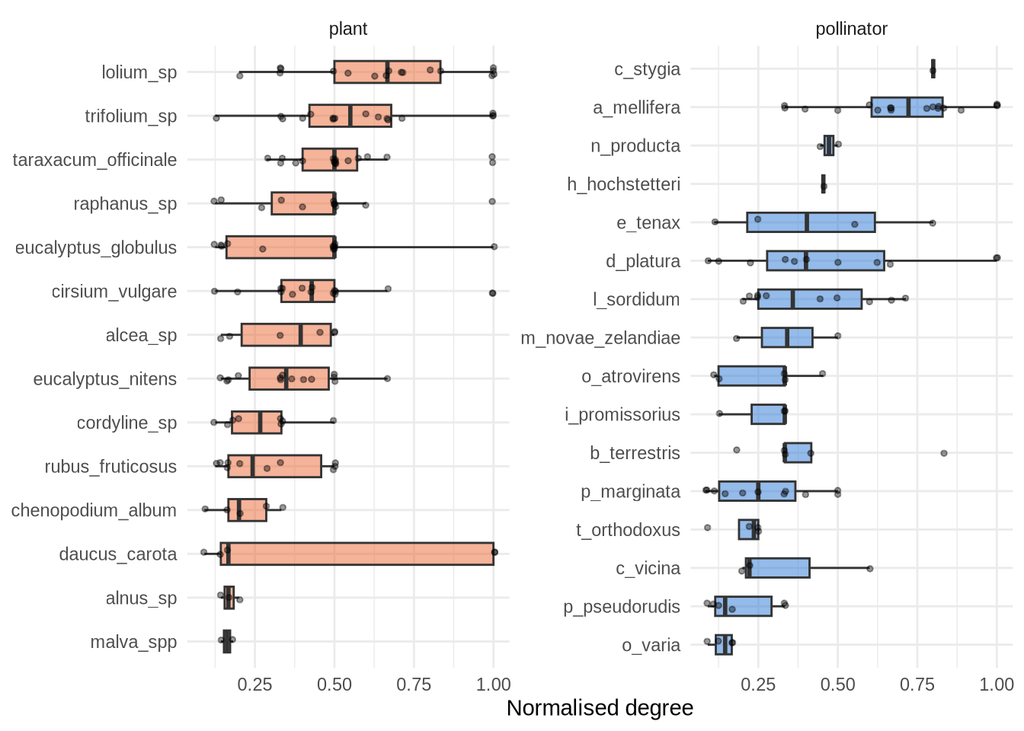

```r
ndegree_by_species <- net_metrics |>
  mutate(species = fct_reorder(species, normalised_degree, .fun = median))

ggplot(ndegree_by_species, aes(x = species, y = normalised_degree, fill = guild)) +
  geom_boxplot(width = 0.5, outlier.shape = NA, alpha = 0.5) +
  geom_jitter(width = 0.1, alpha = 0.4, size = 1) +
  scale_fill_manual(values = guild_colors) +
  facet_wrap(~guild, scales = "free_y") +
  coord_flip() +
  labs(x = NULL, y = "Normalised degree") +
  theme(legend.position = "none")
```

### Specialisation (d′) per species

Same, for Blüthgen’s d′. d′ is `NA` for species in the three smallest networks (all of a species’ partners are only ever visited by it, leaving the normalisation undefined), which `median()`/the boxplot silently drop.

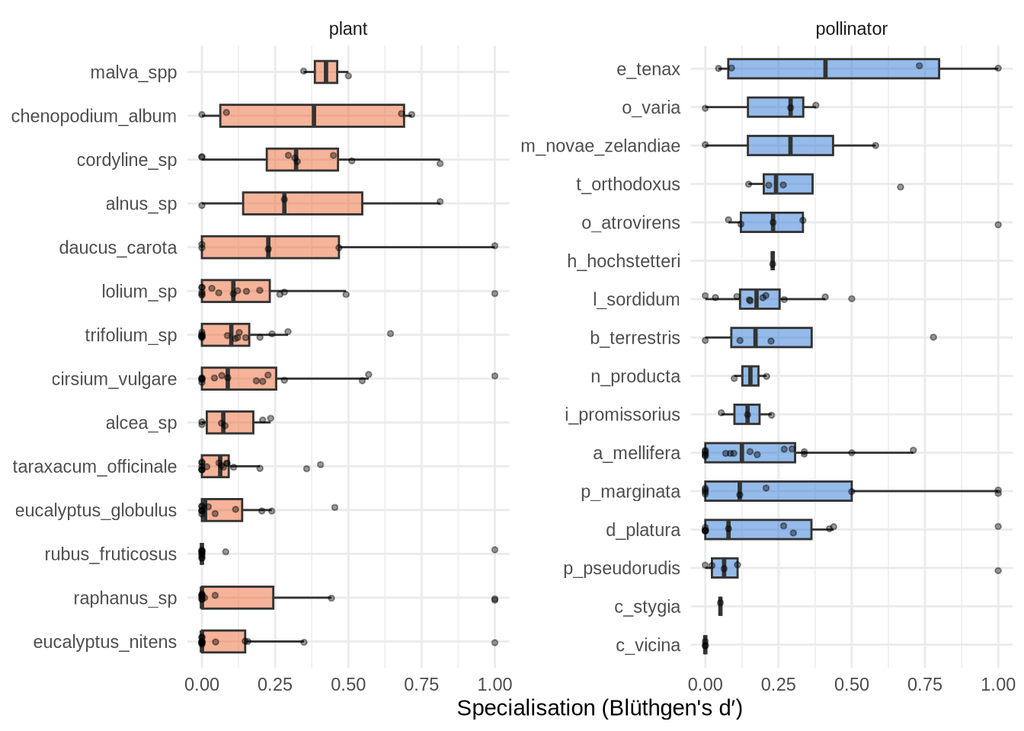

```r
dprime_by_species <- net_metrics |>
  mutate(species = fct_reorder(species, d_prime, .fun = median, na.rm = TRUE))

ggplot(dprime_by_species, aes(x = species, y = d_prime, fill = guild)) +
  geom_boxplot(width = 0.5, outlier.shape = NA, alpha = 0.5) +
  geom_jitter(width = 0.1, alpha = 0.4, size = 1) +
  scale_fill_manual(values = guild_colors) +
  facet_wrap(~guild, scales = "free_y") +
  coord_flip() +
  labs(x = NULL, y = "Specialisation (Blüthgen's d′)") +
  theme(legend.position = "none")
```

### Specificity (HS) per species

HS is the Shannon-based specificity used by Coux et al. (2016), from Poisot’s `ESM` package:

$$\text{HS}_i = 1 - \frac{H_i}{\log R}$$

where $H_i$ is the Shannon entropy of species $i$’s visits across plants and $R$ is the number of plants visited by anyone at the site. A species with a single partner has HS = 1 (a perfect specialist); one spreading its visits evenly over every available plant has HS = 0. Unlike d′, it does not correct for how often each partner is visited overall. See `compute_hs()`.

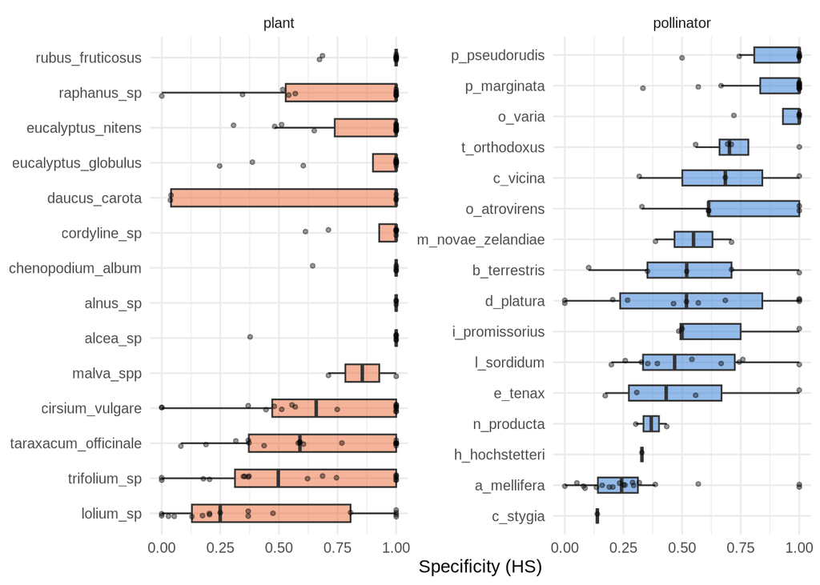

```r
hs_by_species <- net_metrics |>
  mutate(species = fct_reorder(species, hs, .fun = median))

ggplot(hs_by_species, aes(x = species, y = hs, fill = guild)) +
  geom_boxplot(width = 0.5, outlier.shape = NA, alpha = 0.5) +
  geom_jitter(width = 0.1, alpha = 0.4, size = 1) +
  scale_fill_manual(values = guild_colors) +
  facet_wrap(~guild, scales = "free_y") +
  coord_flip() +
  labs(x = NULL, y = "Specificity (HS)") +
  theme(legend.position = "none")
```

### An example network

The richest site, for a sense of what an actual interaction web looks like.

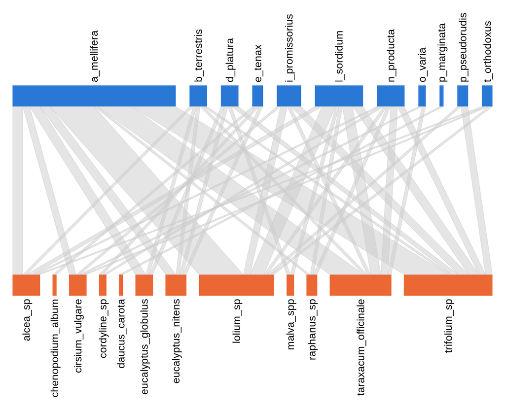

```r
web_list <- tar_read(web_list)
richest_site <- names(web_list)[which.max(vapply(web_list, sum, numeric(1)))]

plotweb(
  web_list[[richest_site]],
  higher_color = guild_colors[["pollinator"]],
  lower_color = guild_colors[["plant"]],
  link_color = "grey80",
  srt = 0,
  text_size = 1
)
```

## Trait overview

We have plant traits: growth form, phenology, flower morphology and nectar reward (14 plants).

```r
str(data$plant_trait)
```

```
'data.frame':   14 obs. of  16 variables:
 $ plant                                 : chr  "lolium_sp" "daucus_carota" "chenopodium_album" "cordyline_sp" ...
 $ growth_form                           : chr  "grass" "herb" "herb" "tree" ...
 $ annual_perennial                      : chr  "annual" "biennial" "annual" "perennial" ...
 $ single_inflo                          : int  2 2 2 2 1 2 2 1 2 2 ...
 $ type_inflorescence                    : int  1 1 1 1 0 1 3 0 2 1 ...
 $ pollnec_access                        : int  1 1 1 1 2 2 1 1 2 1 ...
 $ flowers_per_inflorescence             : int  2 3 2 3 1 1 2 1 2 1 ...
 $ flower_symmetry                       : chr  "zygomorphic" "actinomorphic" "actinomorphic" "actinomorphic" ...
 $ inflorescence_symmetry                : chr  "zygomorphic" "actinomorphic" "actinomorphic" "actinomorphic" ...
 $ spring                                : int  1 0 0 0 0 0 1 0 0 0 ...
 $ summer                                : int  1 1 1 1 1 1 0 1 1 1 ...
 $ fall                                  : int  0 1 1 0 1 0 0 0 0 1 ...
 $ winter                                : int  0 0 0 0 0 0 1 0 0 0 ...
 $ flower_sex                            : chr  "bisexual" "bisexual" "bisexual" "bisexual" ...
 $ floral_fragrance                      : int  1 1 NA 3 2 1 1 1 1 3 ...
 $ amount_of_nectar_per_poll_unit_per_day: int  1 3 1 2 3 3 1 2 2 2 ...
```

We have pollinator traits: body size, foraging preferences, sociality and larval diet (16 pollinators).

```r
str(data$pollinator_trait)
```

```
'data.frame':   16 obs. of  16 variables:
 $ pollinator        : chr  "a_mellifera" "b_terrestris" "c_stygia" "c_vicina" ...
 $ body_length       : num  12 14.3 10.9 9 3.9 14.3 8.6 13 5.5 9.7 ...
 $ body_weigth       : num  4.5 6.8 5.7 4.9 1.6 5.1 3.2 2 1.7 2.2 ...
 $ flw_vis_time      : num  4.1 3.68 NA 10.1 NA ...
 $ pref_nec          : num  100 100 NA 100 NA 75 0 NA 100 14.3 ...
 $ pref_pol          : num  0 0 NA NA NA 25 100 NA 0 85.7 ...
 $ soc_sol           : chr  "social" "social" "solitary" "solitary" ...
 $ larv_necpol       : int  1 1 0 0 0 0 0 0 1 0 ...
 $ larv_plant        : int  0 0 1 1 1 1 1 0 0 0 ...
 $ larv_carr         : int  0 0 1 1 0 0 0 0 0 0 ...
 $ larv_paras        : int  0 0 0 0 0 0 0 1 0 0 ...
 $ larv_dung         : int  0 0 0 0 0 0 0 0 0 0 ...
 $ larv_dinsct       : int  0 0 0 0 0 0 0 0 0 1 ...
 $ Carrying_structure: chr  "corbicula" "corbicula" "None" "None" ...
 $ season            : chr  "Aug" "Jan" "Jun" "Jan" ...
 $ daily             : chr  "X2pm" "X12pm" "X12pm" "X10am" ...
```

### Plant types and annual vs perennial

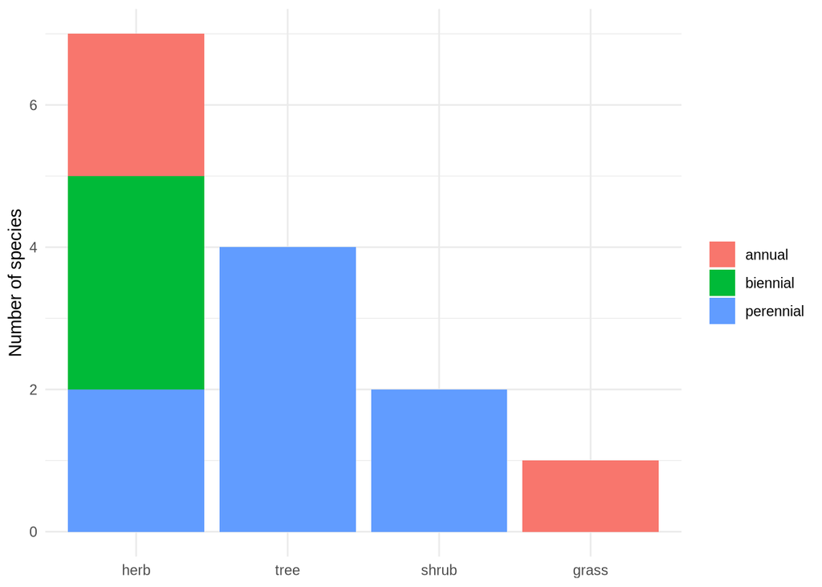

```r
ggplot(
  data$plant_trait,
  aes(x = fct_infreq(growth_form), fill = annual_perennial)
) +
  geom_bar() +
  labs(
    x = NULL, y = "Number of species", fill = NULL
  )
```

### Most pollinators are small-bodied and solitary

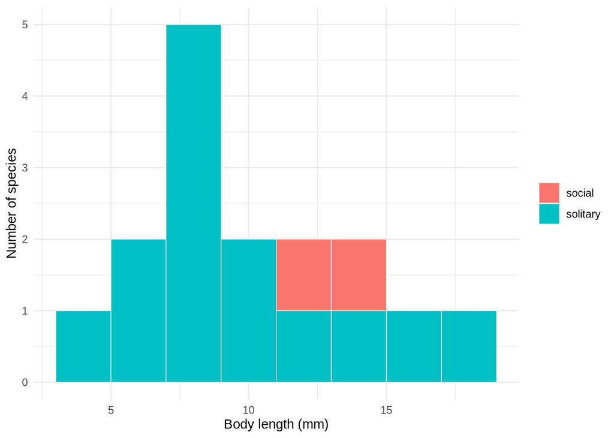

```r
ggplot(data$pollinator_trait, aes(x = body_length, fill = soc_sol)) +
  geom_histogram(binwidth = 2, color = "white", linewidth = 0.2) +
  labs(
    x = "Body length (mm)", y = "Number of species", fill = NULL
  )
```

## Trait spaces

We follow Coux et al. (2016)’s approach: traits are standardised and combined into a single dissimilarity via Gower’s distance, then ordinated with PCoA. To see how each trait contributes to the two ordination axes, we fit every trait separately onto the PCoA scores

### Plant trait space

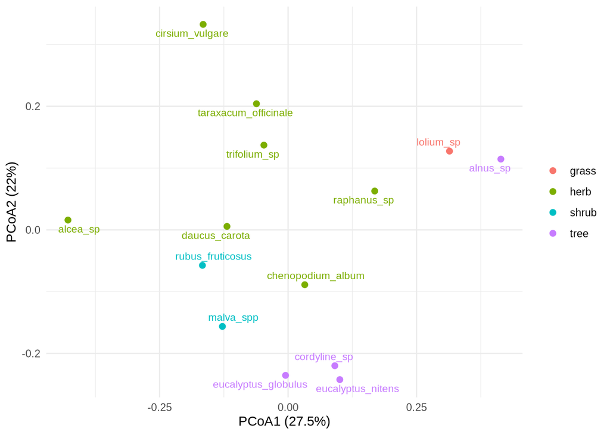

```r
plant_trait_ready <- tar_read(plant_trait_ready)
plant_pcoa <- tar_read(plant_trait_pcoa)
plant_pct <- round(plant_pcoa$values$Rel_corr_eig[1:2] * 100, 1)

plant_pcoa_df <- as.data.frame(plant_pcoa$vectors[, 1:2])
names(plant_pcoa_df) <- c("Axis1", "Axis2")
plant_pcoa_df$plant <- rownames(plant_pcoa_df)
plant_pcoa_df$growth_form <- plant_trait_ready$growth_form

ggplot(plant_pcoa_df, aes(Axis1, Axis2, color = growth_form, label = plant)) +
  geom_point(size = 2) +
  geom_text_repel(size = 3, show.legend = FALSE) +
  labs(
    x = paste0("PCoA1 (", plant_pct[1], "%)"),
    y = paste0("PCoA2 (", plant_pct[2], "%)"),
    color = NULL
  )
```

### Which traits drive the plant trait space

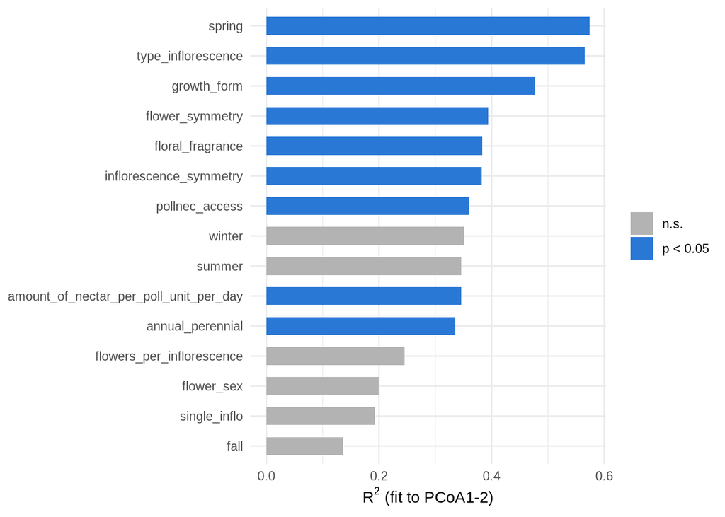

```r
plant_fit <- tar_read(plant_trait_fit)
plot_trait_importance(plant_fit)
```

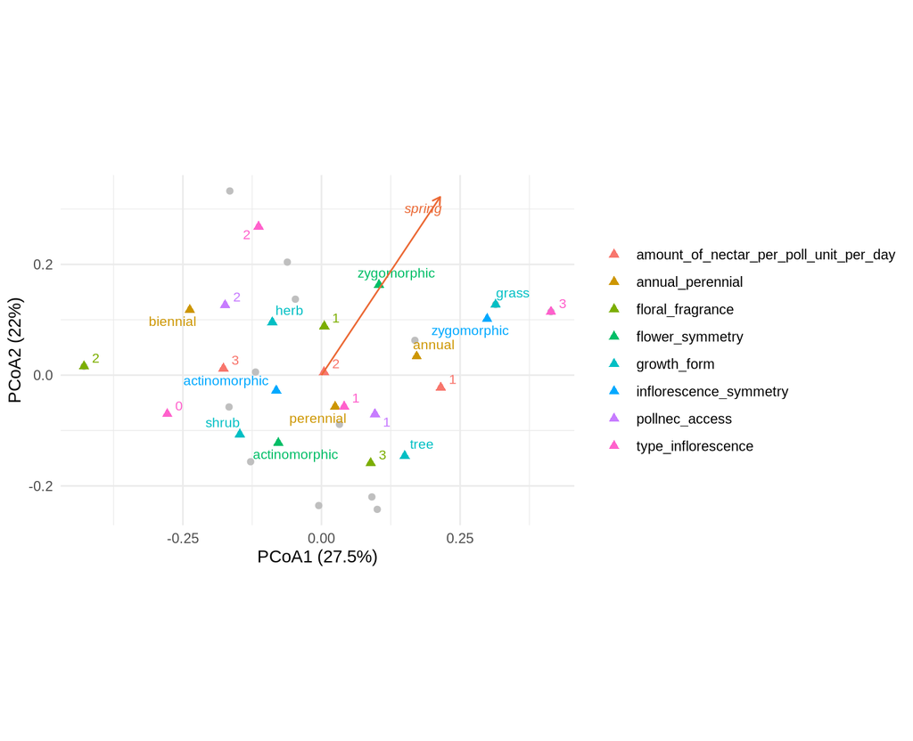

```r
plot_trait_biplot(plant_pcoa, plant_fit, guild_colors[["plant"]])
```

Season splits the space along a diagonal (spring/winter-flowering species vs. the rest), while growth form and inflorescence type separate species mostly along PCoA1 — consistent with the tree/herb split seen above.

### Pollinator trait space

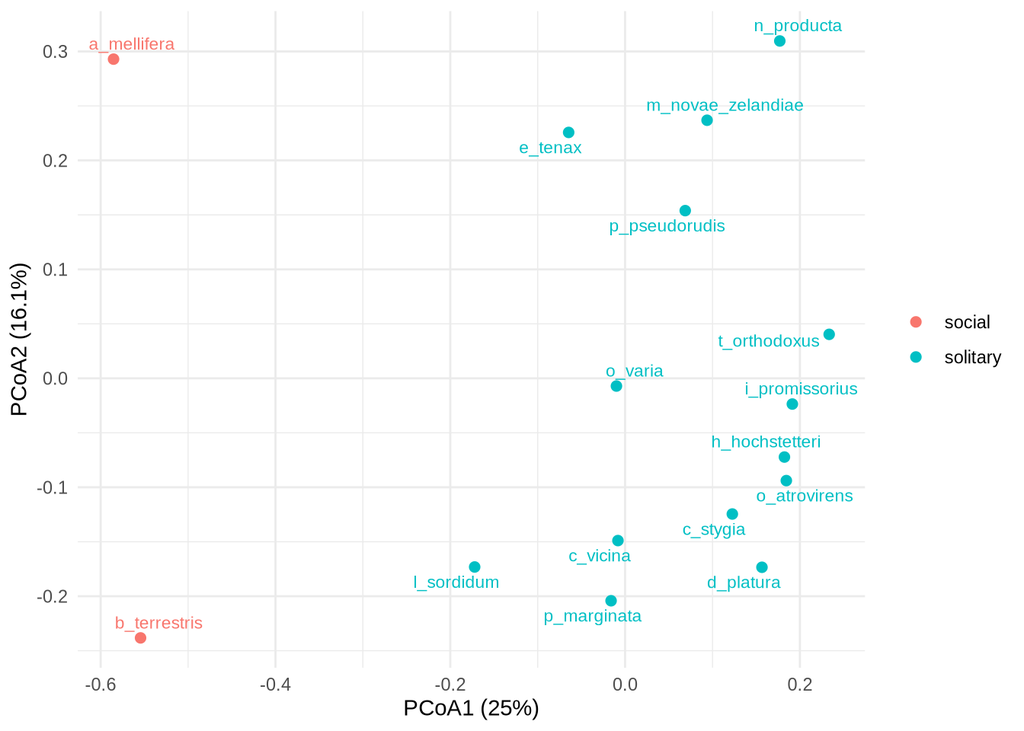

```r
pollinator_trait_ready <- tar_read(pollinator_trait_ready)
pollinator_pcoa <- tar_read(pollinator_trait_pcoa)
pollinator_pct <- round(pollinator_pcoa$values$Rel_corr_eig[1:2] * 100, 1)

pollinator_pcoa_df <- as.data.frame(pollinator_pcoa$vectors[, 1:2])
names(pollinator_pcoa_df) <- c("Axis1", "Axis2")
pollinator_pcoa_df$pollinator <- rownames(pollinator_pcoa_df)
pollinator_pcoa_df$soc_sol <- pollinator_trait_ready$soc_sol

ggplot(
  pollinator_pcoa_df,
  aes(Axis1, Axis2, color = soc_sol, label = pollinator)
) +
  geom_point(size = 2) +
  geom_text_repel(size = 3, show.legend = FALSE) +
  labs(
    x = paste0("PCoA1 (", pollinator_pct[1], "%)"),
    y = paste0("PCoA2 (", pollinator_pct[2], "%)"),
    color = NULL
  )
```

### Which traits drive the pollinator trait space

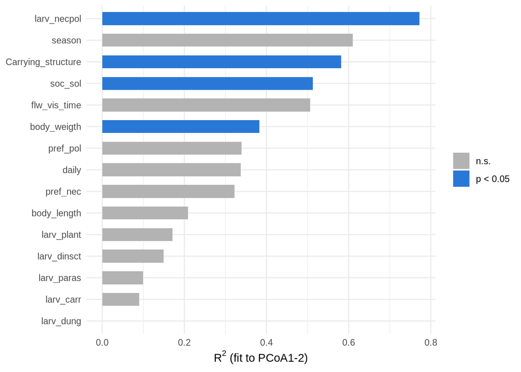

```r
pollinator_fit <- tar_read(pollinator_trait_fit)
plot_trait_importance(pollinator_fit)
```

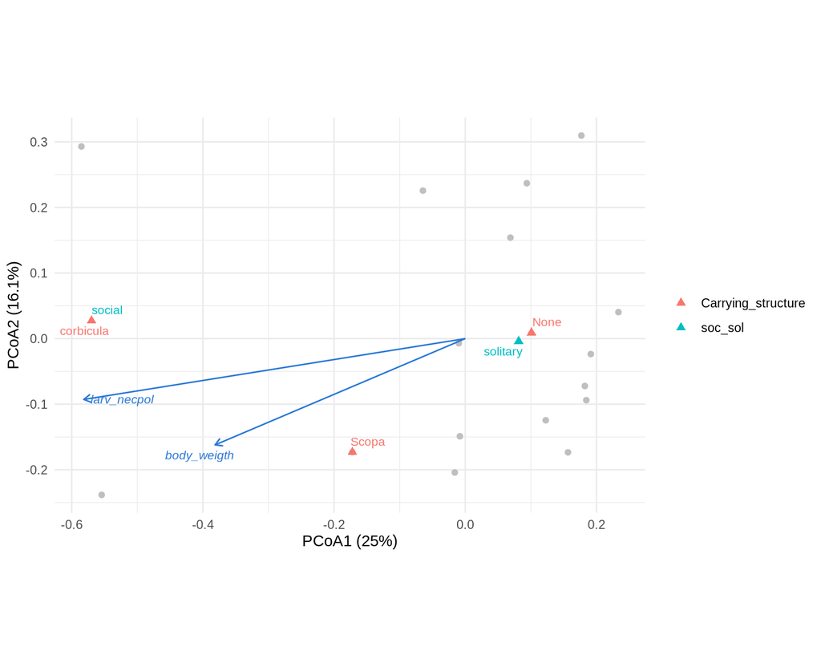

```r
plot_trait_biplot(pollinator_pcoa, pollinator_fit, guild_colors[["pollinator"]])
```

## Uniqueness and originality

### Uniqueness

We compute species uniqueness per species per site. Uniqueness is defined as

$$\text{uniqueness}_i = \min_j d_{ij}$$

that is the minimal functional distance to another species present in the community. Following Coux et al. (2016), $d_{ij}$ is the Euclidean distance in the Cailliez-corrected PCoA space, the same space in which we compute originality below, so that both metrics describe positions in a single trait space. A species alone at its site has no neighbour and is left out.

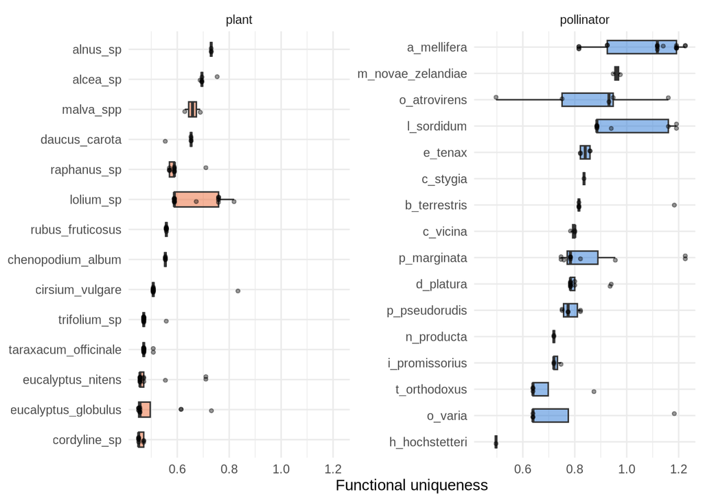

```r
plant_uniqueness <- tar_read(plant_uniqueness)
pollinator_uniqueness <- tar_read(pollinator_uniqueness)
all_uniqueness <- rbind(
  plant_uniqueness |> mutate(guild = "plant"),
  pollinator_uniqueness |> mutate(guild = "pollinator")
) |>
  mutate(species = fct_reorder(species, uniqueness, .fun = median))

ggplot(all_uniqueness, aes(x = species, y = uniqueness, fill = guild)) +
  geom_boxplot(width = 0.5, outlier.shape = NA, alpha = 0.5) +
  geom_jitter(width = 0.1, alpha = 0.4, size = 1) +
  scale_fill_manual(values = guild_colors) +
  facet_wrap(~guild, scales = "free_y") +
  coord_flip() +
  labs(x = NULL, y = "Functional uniqueness") +
  theme(legend.position = "none")
```

### Originality

Functional originality is the distance of a species from the trait centroid of the community it belongs to, i.e. how much its traits differ from the community’s average:

$$\text{originality}_i = \lVert x_i - \bar{x}_{\text{community}} \rVert$$

We compute it per species per site in the PCoA trait space, with the centroid taken over the species present at each site.

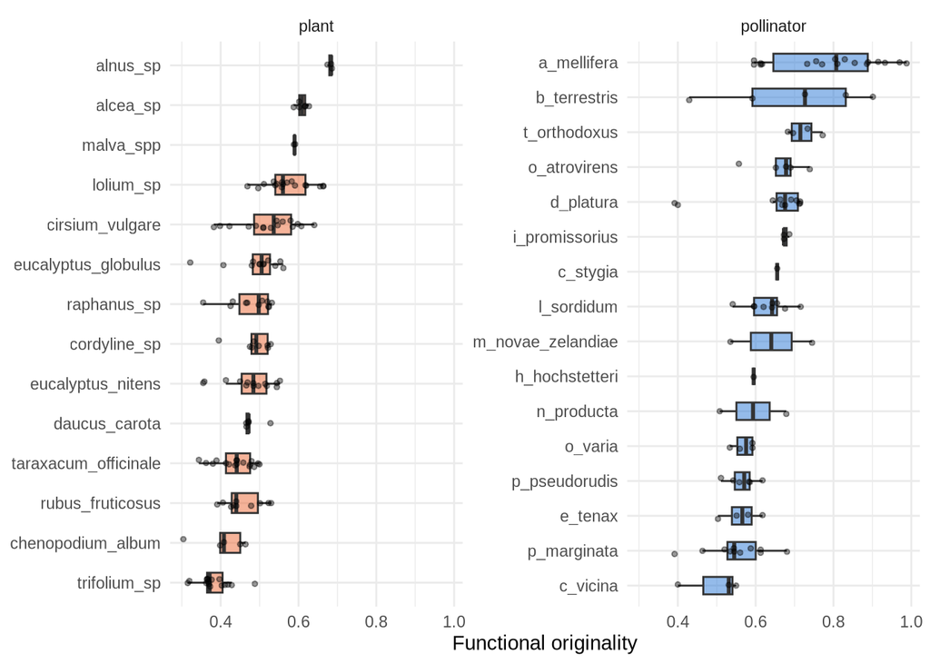

```r
plant_originality <- tar_read(plant_originality)
pollinator_originality <- tar_read(pollinator_originality)
all_originality <- rbind(
  plant_originality |> mutate(guild = "plant"),
  pollinator_originality |> mutate(guild = "pollinator")
) |>
  mutate(species = fct_reorder(species, originality, .fun = median))

ggplot(all_originality, aes(x = species, y = originality, fill = guild)) +
  geom_boxplot(width = 0.5, outlier.shape = NA, alpha = 0.5) +
  geom_jitter(width = 0.1, alpha = 0.4, size = 1) +
  scale_fill_manual(values = guild_colors) +
  facet_wrap(~guild, scales = "free_y") +
  coord_flip() +
  labs(x = NULL, y = "Functional originality") +
  theme(legend.position = "none")
```

### Weighted originality

Above, the community centroid treats every present species equally. For pollinators we also have abundance data, so we can instead weight the centroid by how common each species is at a site.

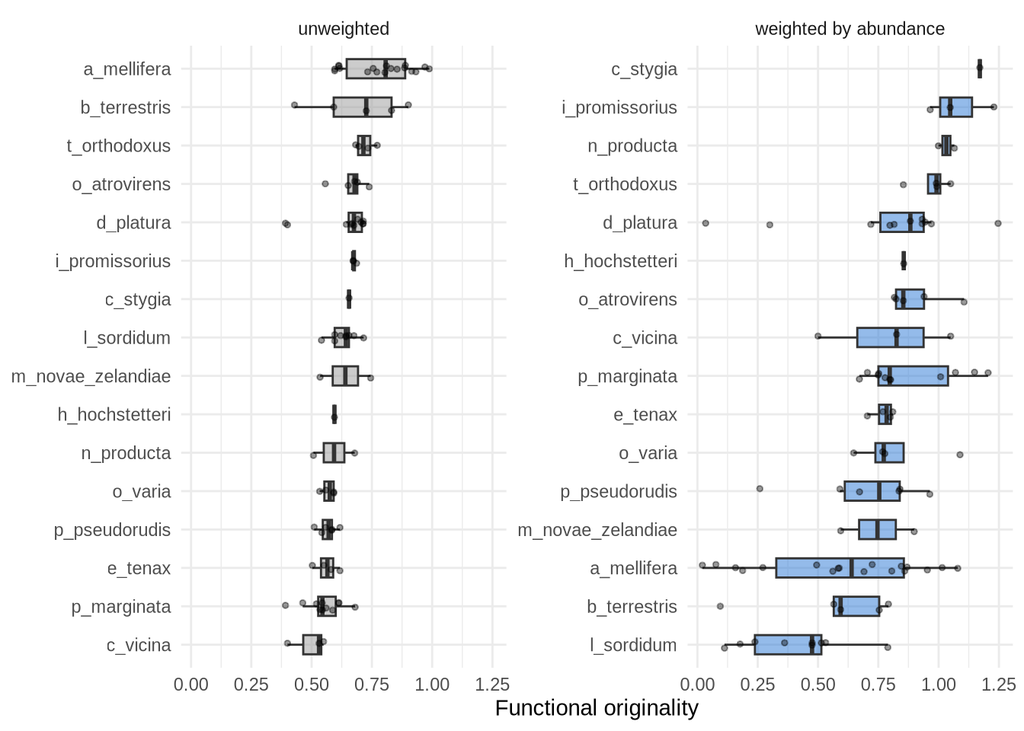

```r
pollinator_originality_w <- tar_read(pollinator_originality_w)

originality_comparison <- rbind(
  pollinator_originality |> mutate(weighting = "unweighted"),
  pollinator_originality_w |> mutate(weighting = "weighted by abundance")
) |>
  mutate(
    weighting = factor(
      weighting,
      levels = c("unweighted", "weighted by abundance")
    ),
    species_within = reorder(
      paste(species, weighting, sep = "___"), originality,
      FUN = median
    )
  )

ggplot(
  originality_comparison,
  aes(x = species_within, y = originality, fill = weighting)
) +
  geom_boxplot(width = 0.5, outlier.shape = NA, alpha = 0.5) +
  geom_jitter(width = 0.1, alpha = 0.4, size = 1) +
  scale_fill_manual(
    values = c(
      "unweighted" = "grey60",
      "weighted by abundance" = guild_colors[["pollinator"]]
    )
  ) +
  scale_x_discrete(labels = \(x) sub("___.*$", "", x)) +
  facet_wrap(~weighting, scales = "free_y") +
  coord_flip() +
  labs(x = NULL, y = "Functional originality") +
  theme(legend.position = "none")
```

We see that ranking shift with weighting. Common generalist, such `a_mellifera` drop in originality as they pull the community weighted mean, while rarer species such as `n_producta` increase in originality.

To check, to what extent species abundance drive their originality we plot species weighted originality against their abundance for each site.

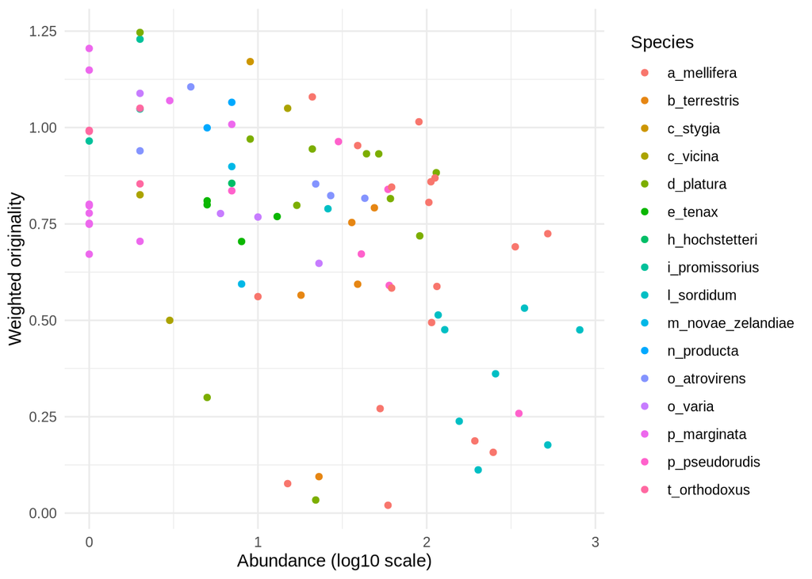

```r
pollinator_abundance <- data$pollinator_abundance |>
  pivot_longer(
    cols = a_mellifera:t_orthodoxus,
    names_to = "species",
    values_to = "abundance"
  ) |>
  filter_out(abundance == 0)

originality_abundance <- pollinator_originality_w |>
  left_join(pollinator_abundance, by = join_by(site, species))

ggplot(
  originality_abundance,
  aes(x = log10(abundance), y = originality, color = species),
) +
  geom_point() +
  labs(
    x = "Abundance (log10 scale)",
    y = "Weighted originality",
    color = "Species"
  )
```

We see that there is strong negative correlation between weighted originality and species abundance. This means that we should be careful if we use this metric.

### Originality vs uniqueness

Next, we want to check that species originality and uniqueness are not too strongly correlated, to ensure that the two metrics are complementary description of species position in the functional space.

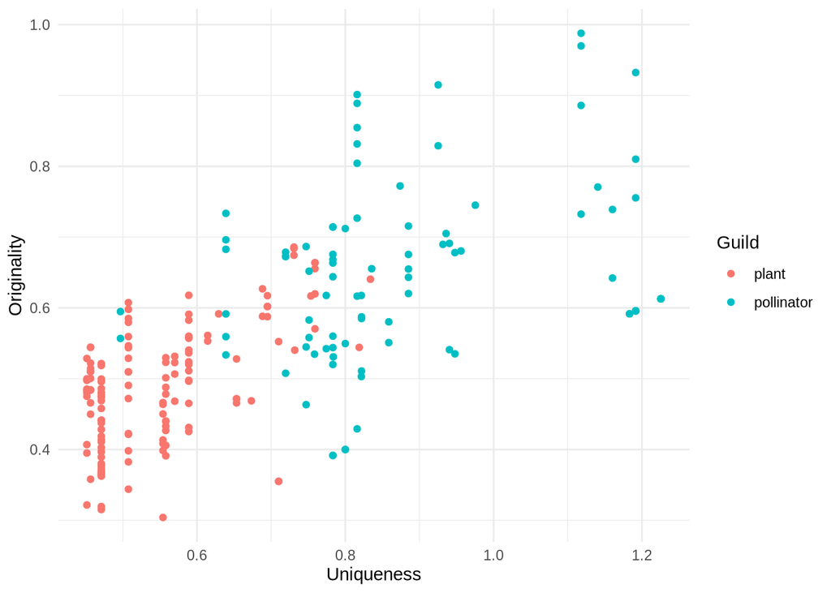

```r
pol_originality_uniqueness <- pollinator_originality |>
  left_join(pollinator_uniqueness, by = join_by(site, species))

plant_originality_uniqueness <- plant_originality |>
  left_join(plant_uniqueness, by = join_by(site, species))

originality_uniqueness <- rbind(
  plant_originality_uniqueness |> mutate(guild = "plant"),
  pol_originality_uniqueness |> mutate(guild = "pollinator")
)

ggplot(
  originality_uniqueness,
  aes(x = uniqueness, y = originality, color = guild)
) +
  geom_point() +
  labs(x = "Uniqueness", y = "Originality", color = "Guild")
```

```r
head(tar_read(net_metrics))
```

```
# A tibble: 6 × 7
  site      species        degree normalised_degree d_prime guild         hs
  <chr>     <chr>           <dbl>             <dbl>   <dbl> <chr>      <dbl>
1 blabrolee a_mellifera         7             0.778  0.177  pollinator 0.190
2 blabrolee e_tenax             1             0.111  1      pollinator 1
3 blabrolee i_promissorius      3             0.333  0.144  pollinator 0.5
4 blabrolee l_sordidum          2             0.222  0.207  pollinator 0.744
5 blabrolee n_producta          4             0.444  0.209  pollinator 0.435
6 blabrolee p_pseudorudis       3             0.333  0.0227 pollinator 0.5
```

## Interaction niche

Following Dehling & Stouffer (2018) and Dehling et al. (2022), a species’ interaction niche describes it through the traits of its interaction partners rather than its own traits: its *position* is the (link-weighted) centroid of its partners’ traits in the partner guild’s trait space, its *size* is how dispersed those partners are around that centroid, and its *originality* is how far that centroid sits from the average position of its guild-mates at the same site.

We use dispersion rather than a hull/hypervolume for niche size: partner counts here are low (median degree 1-2.5 per the degree distributions above), too low for a hull-based volume to be defined for most species, whereas a dispersion-based measure degrades gracefully — a species with a single partner simply gets a niche size of 0.

### Niche size

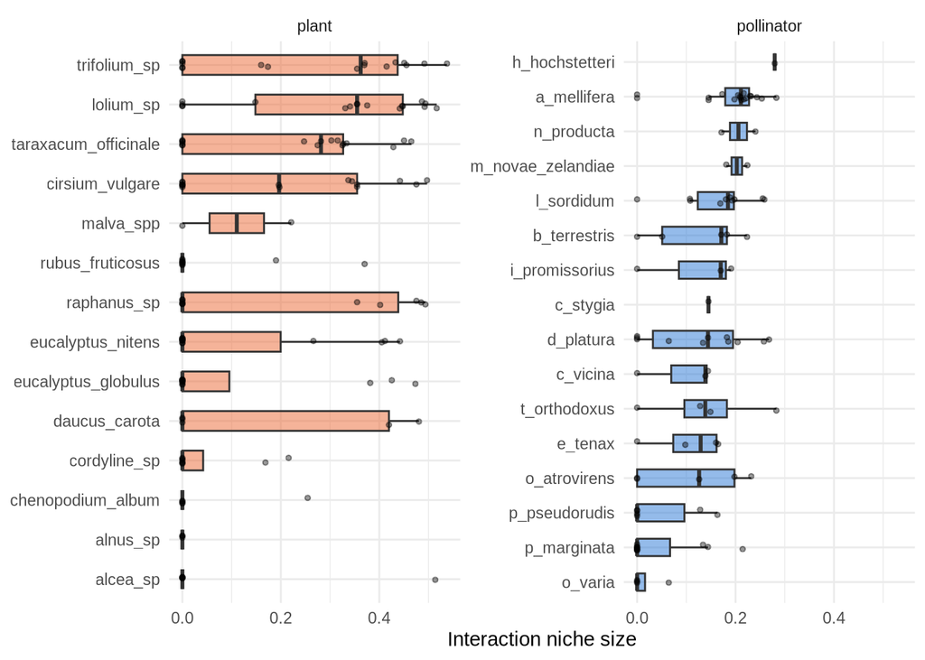

```r
plant_interaction_niche <- tar_read(plant_interaction_niche)
pollinator_interaction_niche <- tar_read(pollinator_interaction_niche)
all_interaction_niche <- rbind(
  plant_interaction_niche |> mutate(guild = "plant"),
  pollinator_interaction_niche |> mutate(guild = "pollinator")
)

niche_size_by_species <- all_interaction_niche |>
  mutate(species = fct_reorder(species, niche_size, .fun = median))

ggplot(niche_size_by_species, aes(x = species, y = niche_size, fill = guild)) +
  geom_boxplot(width = 0.5, outlier.shape = NA, alpha = 0.5) +
  geom_jitter(width = 0.1, alpha = 0.4, size = 1) +
  scale_fill_manual(values = guild_colors) +
  facet_wrap(~guild, scales = "free_y") +
  coord_flip() +
  labs(x = NULL, y = "Interaction niche size") +
  theme(legend.position = "none")
```

### Niche originality

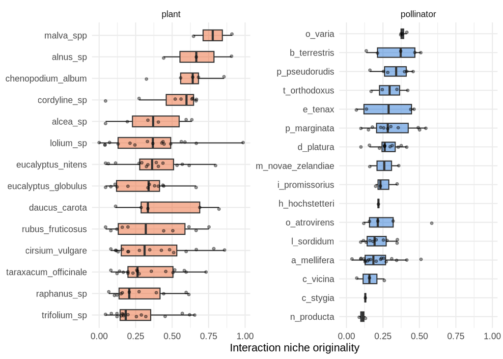

```r
niche_originality_by_species <- all_interaction_niche |>
  mutate(species = fct_reorder(species, niche_originality, .fun = median))

ggplot(
  niche_originality_by_species,
  aes(x = species, y = niche_originality, fill = guild)
) +
  geom_boxplot(width = 0.5, outlier.shape = NA, alpha = 0.5) +
  geom_jitter(width = 0.1, alpha = 0.4, size = 1) +
  scale_fill_manual(values = guild_colors) +
  facet_wrap(~guild, scales = "free_y") +
  coord_flip() +
  labs(x = NULL, y = "Interaction niche originality") +
  theme(legend.position = "none")
```

## Pollinator origin

We get for each species whether they are native to New-Zealand or have been introduced. We do so to get a rough sense whether species native status might drive some of the patterns we observe. This is motivated by the dominance of the honeybee (A. Mellifera) which is an introduced species.

```r
pollinator_annotation <- tar_read(pollinator_annotation)
pollinator_annotation |>
  select(species_name, origin, origin_confidence) |>
  arrange(origin, species_name) |>
  knitr::kable()
```

| species_name | origin | origin_confidence |
| --- | --- | --- |
| Helophilus hochstetteri | native | high |
| Lasioglossum sordidum | native | high |
| Melangyna novaezelandiae | native | high |
| Odontomyia atrovirens | native | low |
| Pales marginata | native | medium |
| Apis mellifera | introduced | high |
| Bombus terrestris | introduced | high |
| Calliphora stygia | introduced | high |
| Calliphora vicina | introduced | high |
| Delia platura | introduced | medium |
| Eristalis tenax | introduced | high |
| Ichneumon promissorius | introduced | medium |
| Netelia producta | introduced | low |
| Oxysarcodexia varia | introduced | high |
| Pollenia pseudorudis | introduced | high |
| Thyreocephalus orthodoxus | introduced | high |

Eleven of the 16 pollinator species are introduced. They also make up more than half of the pollinator species at 13 of the 21 sites.

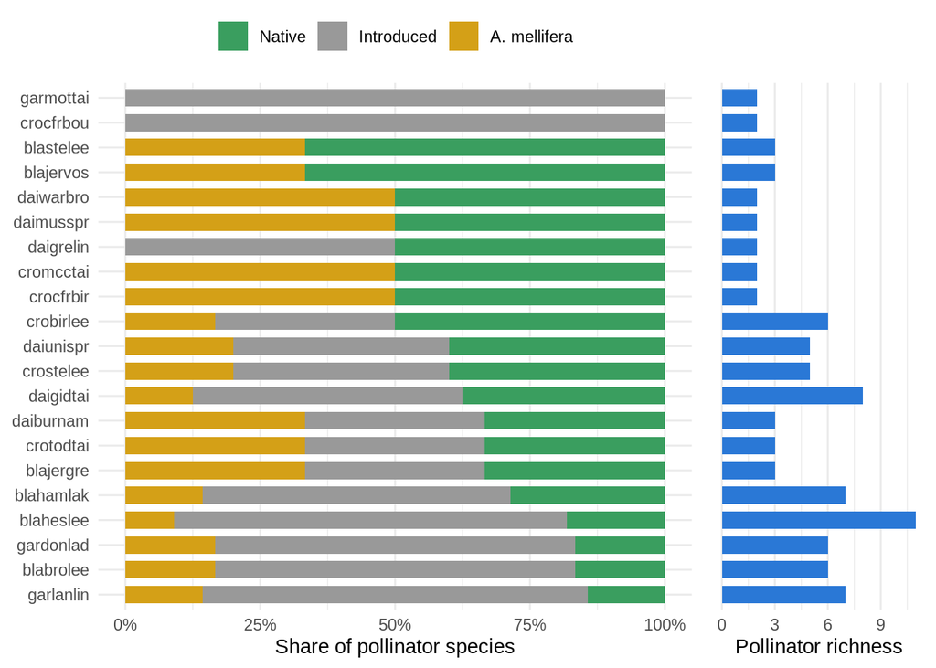

```r
origin_share <- data$pollinator_abundance |>
  pivot_longer(-site, names_to = "pollinator", values_to = "abundance") |>
  filter(abundance > 0) |>
  mutate(presence = 1) |>
  left_join(pollinator_annotation, by = join_by(pollinator)) |>
  mutate(
    class = case_when(
      pollinator == "a_mellifera" ~ "A. mellifera",
      origin == "native" ~ "Native",
      origin == "introduced" ~ "Introduced"
    ),
    class = factor(class, levels = c("Native", "Introduced", "A. mellifera"))
  ) |>
  group_by(site, class) |>
  summarise(class_richness = sum(presence), .groups = "drop_last") |>
  mutate(share = class_richness / sum(class_richness)) |>
  ungroup()

native_order <- origin_share |>
  filter(class == "Native") |>
  arrange(share) |>
  pull(site)

origin_colors <- c(
  Native = "#3a9e5f", Introduced = "grey60", `A. mellifera` = "#d4a017"
)

site_order <- union(native_order, unique(origin_share$site))

p_share <- origin_share |>
  mutate(site = factor(site, levels = site_order)) |>
  ggplot(aes(x = site, y = share, fill = class)) +
  geom_col(width = 0.7) +
  coord_flip() +
  scale_fill_manual(values = origin_colors) +
  scale_y_continuous(labels = scales::percent) +
  labs(x = NULL, y = "Share of pollinator species", fill = NULL) +
  theme(legend.position = "top")

pollinator_richness <- site_richness |>
  filter(guild == "pollinator") |>
  mutate(site = factor(site, levels = site_order))

p_richness <- ggplot(pollinator_richness, aes(x = site, y = n_species)) +
  geom_col(width = 0.7, fill = guild_colors[["pollinator"]]) +
  coord_flip() +
  labs(x = NULL, y = "Pollinator richness") +
  theme(
    axis.text.y = element_blank(),
    panel.grid.major.y = element_blank()
  )

cowplot::plot_grid(
  p_share, p_richness,
  nrow = 1, rel_widths = c(3, 1), align = "h", axis = "tb"
)
```

## Does functional originality predicts pollinator specialism

Coux et al. (2016) report that a pollinator’s functional originality predicts its role in the network: its normalised degree (ND) and its specificity (HS). Their models regress ND and HS on *abundance-weighted* originality and on abundance, plus a few other terms with small effects that we leave aside here.

```r
pollinator_trait_network <- tar_read(pollinator_trait_network)
trait_network_models <- tar_read(trait_network_models)
trait_network_models_richness <- tar_read(trait_network_models_richness)

# Format a coefficient as "mean [lower, upper]".
coef_text <- function(tbl, response, model, term) {
  row <- tbl[tbl$response == response & tbl$model == model &
    tbl$term == term, ]
  sprintf("%.2f [%.2f, %.2f]", row$mean, row$lower, row$upper)
}
spearman <- function(x, y) {
  sprintf("%.2f", cor(x, y, method = "spearman"))
}
```

### Weighted and unweighted originality

When weighting the community centroid by abundance an abundant species drags the centroid towards itself. The more abundant you are, the closer you sit to the centroid, and the less “original” you look.

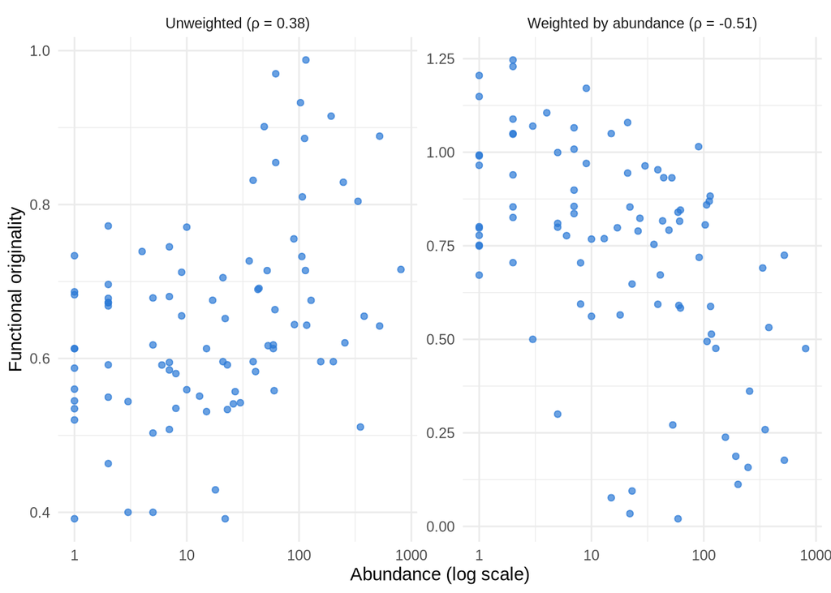

```r
originality_vs_abundance <- pollinator_trait_network |>
  select(site, species, abundance, originality, originality_w) |>
  pivot_longer(
    c(originality, originality_w),
    names_to = "measure", values_to = "value"
  ) |>
  mutate(
    measure = factor(
      measure,
      levels = c("originality", "originality_w"),
      labels = c(
        paste0(
          "Unweighted (ρ = ",
          spearman(
            pollinator_trait_network$originality,
            log(pollinator_trait_network$abundance)
          ), ")"
        ),
        paste0(
          "Weighted by abundance (ρ = ",
          spearman(
            pollinator_trait_network$originality_w,
            log(pollinator_trait_network$abundance)
          ), ")"
        )
      )
    )
  )

ggplot(originality_vs_abundance, aes(x = abundance, y = value)) +
  geom_point(color = guild_colors[["pollinator"]], alpha = 0.7) +
  scale_x_log10() +
  facet_wrap(~measure, scales = "free_y") +
  labs(x = "Abundance (log scale)", y = "Functional originality")
```

### The models

We fit the model of Coux et al. (2016) and the same model with unweighted originality, for both responses:

- **ND ~ weighted originality + abundance** (as in Coux et al.)
- **ND ~ originality + abundance**
- and the same two models for **HS**.

All models are mixed models fitted with `INLA`, with site and species as random intercepts

- **ND** is modelled as a binomial: the number of plants a pollinator visits, out of the plants at its site.
- **HS** is modelled as Gaussian, like the linear mixed models of Coux et al. That’s a crude choice for a measure bounded by 0 and 1, with every single-partner species sitting exactly at 1, but it keeps the comparison with their analysis honest.

Abundance is log-transformed. All predictors are standardised, so coefficients are per standard deviation, on the link scale.

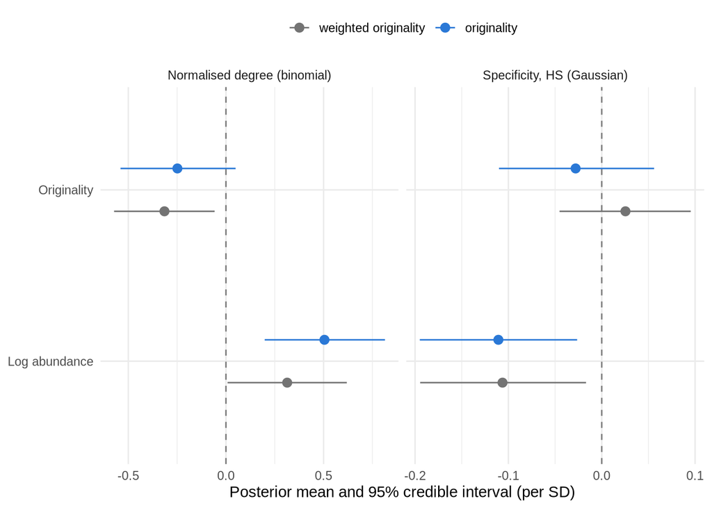

```r
term_labels <- c(
  originality_z = "Originality",
  originality_w_z = "Originality",
  log_abundance_z = "Log abundance",
  log_n_plants_z = "Log plant richness"
)
response_labels <- c(
  degree = "Normalised degree (binomial)",
  hs = "Specificity, HS (Gaussian)"
)
model_colors <- c(
  `weighted originality` = "grey45",
  originality = guild_colors[["pollinator"]]
)

plot_coefficients <- function(tbl) {
  tbl |>
    filter(term != "(Intercept)") |>
    mutate(
      term = factor(
        term_labels[term],
        levels = rev(unique(term_labels))
      ),
      response = factor(
        response_labels[response],
        levels = response_labels
      ),
      model = factor(model, levels = names(model_colors))
    ) |>
    ggplot(aes(x = mean, y = term, color = model)) +
    geom_vline(xintercept = 0, linetype = "dashed", color = "grey50") +
    geom_pointrange(
      aes(xmin = lower, xmax = upper),
      position = position_dodge(width = 0.5)
    ) +
    scale_color_manual(values = model_colors) +
    facet_wrap(~response, scales = "free_x") +
    labs(
      x = "Posterior mean and 95% credible interval (per SD)",
      y = NULL, color = NULL
    ) +
    theme(legend.position = "top")
}

plot_coefficients(trait_network_models)
```

## References

Coux, Camille, Romina Rader, Ignasi Bartomeus, and Jason M. Tylianakis. 2016. “Linking Species Functional Roles to Their Network Roles.” *Ecology Letters* 19 (7): 762–70. https://doi.org/10.1111/ele.12612.